# Modeling CTG Data

Ada Lazuli

2022-07-05

# Data Loading

Load the data for modeling. During exploratory analysis, it was discovered that the classifications for **NSP** are not balanced. The `initial_split` function from `rsample` in `tidymodels` is used to split the data into training and test sets, while preserving the distribution of the **NSP** variable (Silge).

```r
df <- read.csv("CTG.csv")
# convert the classes to factors
df$CLASS <- NULL
df$NSP <- as.factor(df$NSP)
data_partitioned <- initial_split(df, prop = 0.75, strata = NSP)
train <- training(data_partitioned)
test <-  testing(data_partitioned)
```

# Tree Creation

## First Attempt

### Model Definition

The first attempt involved using all of the available features and not specifying any limitations to the model. The tree is created using the `parsnip` package in `tidymodels`, with the *rpart* engine and set for classification (Kuhn). The tree was fit on the data, using all of the available columns

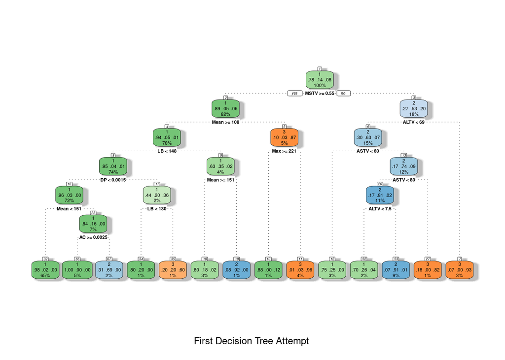

```r
tree_template <- decision_tree() %>% set_engine("rpart") %>% set_mode("classification")
tree_model <- tree_template %>% fit(formula = NSP ~ ., data =  train)
fancyRpartPlot(tree_model$fit, caption = "First Decision Tree Attempt")
```

### Model Results

To assess the performance of the tree, the accuracy, confusion matrix, ROC Curve, and AUC are all captured (Han et al, 2011, p. 49).

```r
# For the confusion Matrix
predictions <- predict(tree_model, test) %>% mutate(true = test$NSP)
# For the plot of the ROC Curve
predictions_prob <- predict(tree_model, test, type = "prob") %>% bind_cols(test)
accuracy(data = predictions, estimate = .pred_class, truth = true)
```

```
## # A tibble: 1 × 3
##   .metric  .estimator .estimate
##   <chr>    <chr>          <dbl>
## 1 accuracy multiclass     0.917
```

```r
conf_mat(data = predictions, estimate = .pred_class, truth = true)
```

```
##           Truth
## Prediction   1   2   3
##          1 396  24   1
##          2  11  52   1
##          3   4   3  40
```

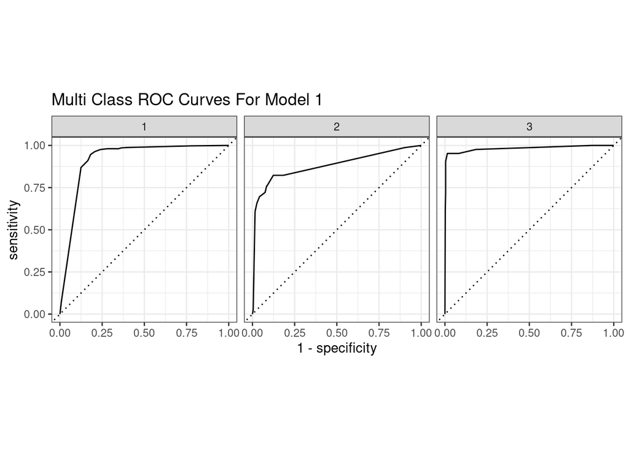

```r
autoplot(roc_curve(data = predictions_prob, estimate = c(.pred_1, .pred_2, .pred_3), truth = NSP)) + ggtitle("Multi Class ROC Curves For Model 1")
```

```r
print(roc_auc(data = predictions_prob, estimate = c(.pred_1, .pred_2, .pred_3), truth = NSP))
```

```
## # A tibble: 1 × 3
##   .metric .estimator .estimate
##   <chr>   <chr>          <dbl>
## 1 roc_auc hand_till      0.926
```

**Note**: The article written by Brendan Cullen (2021) [here](https://bcullen.rbind.io/post/2020-06-02-tidymodels-decision-tree-learning-in-r/) helped a bit with using features available in the collection packages found in tidymodels.

## Second Attempt

### Optimization

The second attempt is to use a grid search to find the optimal combination of *min_n, tree depth, and cost complexity* for the model using `tune_grid` from the `tidymodels` set of packages (Kuhn).

```r
tune_specification <- decision_tree(tree_depth = tune(), min_n = tune(), cost_complexity = tune()) %>% set_mode("classification") %>% set_engine("rpart")

grid_search <- grid_regular(parameters(tune_specification), levels = 10)
```

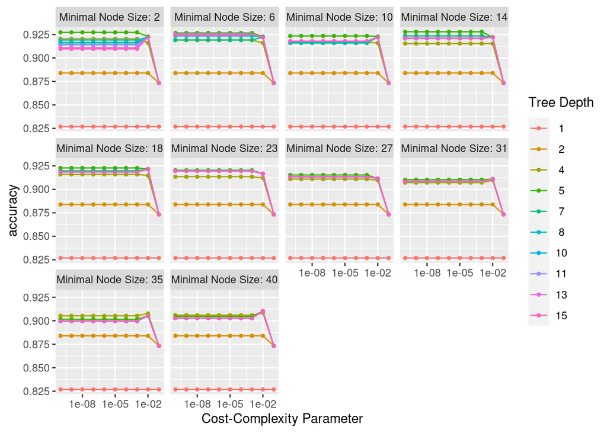

```r
tuned <- tune_grid(tune_specification, NSP ~ ., resample = vfold_cv(train, v = 3), grid = grid_search, metrics = metric_set(accuracy))

autoplot(tuned)
```

### Using Best Parameters

Following the grid search, the best performing set of parameters were saved and used to create a second model.

```r
optimal_parameters <- select_best(tuned)
print(optimal_parameters)
```

```
## # A tibble: 1 × 4
##   cost_complexity tree_depth min_n .config
##             <dbl>      <int> <int> <chr>
## 1    0.0000000001          5    14 Preprocessor1_Model0331
```

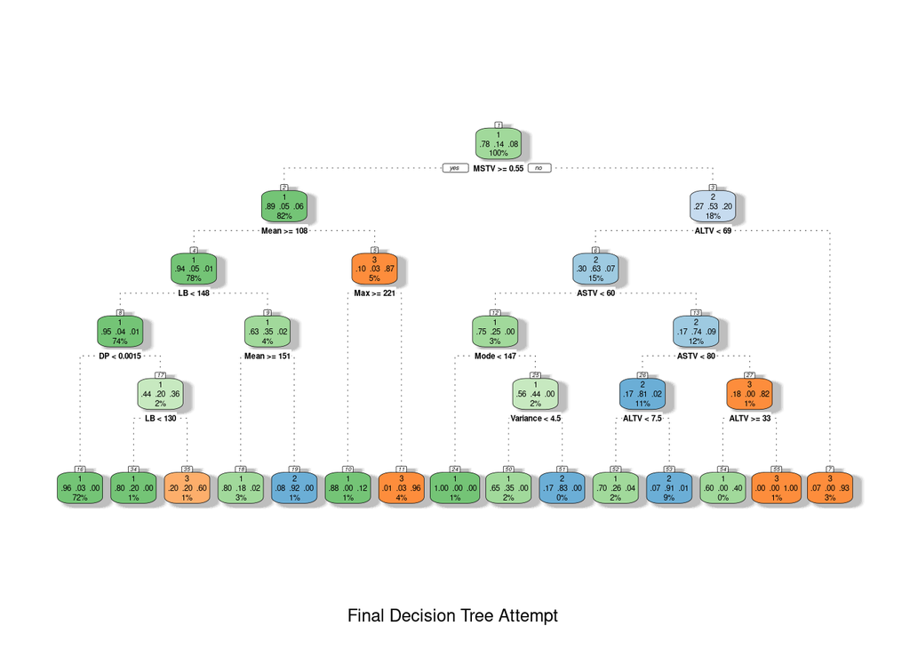

```r
optimal_tree_specification <- finalize_model(tune_specification, optimal_parameters)

optimal_model <- fit(optimal_tree_specification,
                   NSP ~ .,
                   train)

fancyRpartPlot(optimal_model$fit, caption = "Final Decision Tree Attempt")
```

### Model Performance

To assess the performance of the tree, the accuracy, confusion matrix, ROC Curve, and AUC are all captured (Han et al, 2011, p. 49).

```r
predictions <- predict(optimal_model, test) %>% mutate(true = test$NSP)
predictions_prob <- predict(optimal_model, test, type = "prob") %>% bind_cols(test)
accuracy(data = predictions, estimate = .pred_class, truth = true)
```

```
## # A tibble: 1 × 3
##   .metric  .estimator .estimate
##   <chr>    <chr>          <dbl>
## 1 accuracy multiclass     0.912
```

```r
conf_mat(data = predictions, estimate = .pred_class, truth = true)
```

```
##           Truth
## Prediction   1   2   3
##          1 400  27   5
##          2   7  49   1
##          3   4   3  36
```

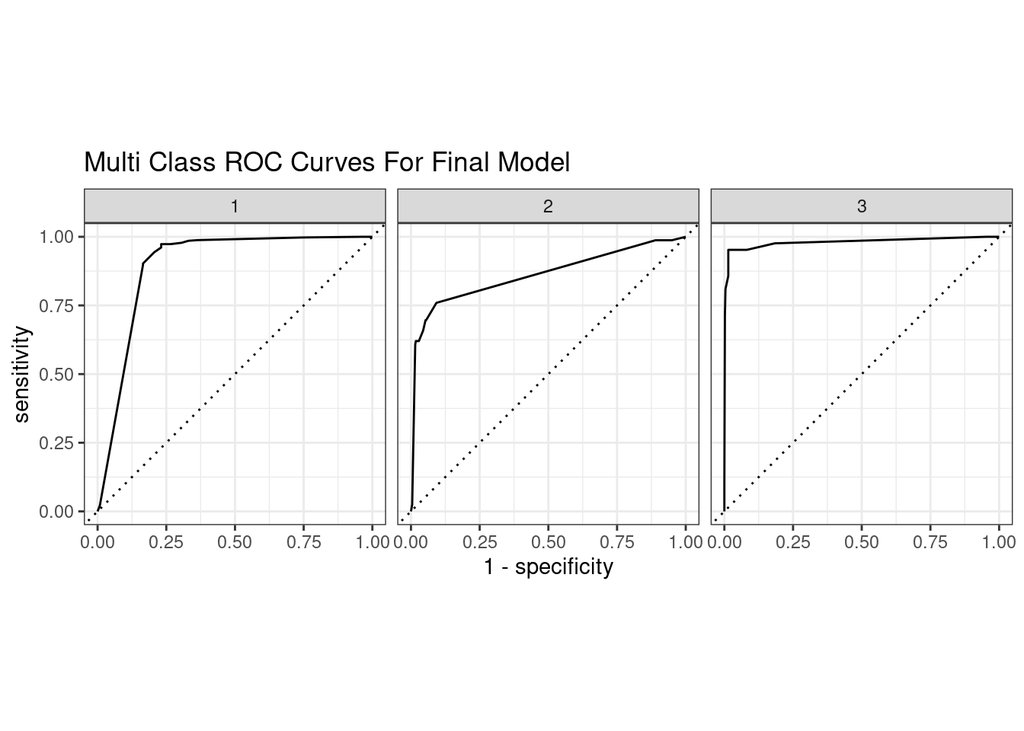

```r
autoplot(roc_curve(data = predictions_prob, estimate = c(.pred_1, .pred_2, .pred_3), truth = NSP)) + ggtitle("Multi Class ROC Curves For Final Model")
```

```r
print(roc_auc(data = predictions_prob, estimate = c(.pred_1, .pred_2, .pred_3), truth = NSP))
```

```
## # A tibble: 1 × 3
##   .metric .estimator .estimate
##   <chr>   <chr>          <dbl>
## 1 roc_auc hand_till      0.932
```

# References

Han, Kamber, & Pei. (2011). Chapter 8. Classification: Basic Concepts. Elsevier Science. Kuhn, M. (n.d.) *Model Tuning Via Grid Search* Retrieved from: https://tune.tidymodels.org/reference/tune_grid.html Kuhn, M. (n.d.) *Decision Trees*. Retrieved from: https://parsnip.tidymodels.org/reference/decision_tree.html Silge, J. (n.d). *Simple Training/Test Set Splitting*. Retrieved from: https://rsample.tidymodels.org/reference/initial_split.html